# Project: Investigate The TMDB dataset

- Introduction
- Data Wrangling
- Exploratory Data Analysis

Question 1: Actor appearances

Question 2: Top movies

Question 3: Movie categories

Question 4: Vote distribution

Question 5: Correlations

- Conclusions

## Introduction

> The Movie Database(TMDB) is a community built movie and TV database. Every piece of data has been added by the community since 2008. TMDB is focused on creating a breadth of data that is strong on international focus.

> In this report, various questions will be answered. For example which actors have appeared on most movies, the most popular movie genres, the revenues, budget and how they correlate with each other

```python
import pandas as pd
import numpy as np
import seaborn as sns
import operator
import matplotlib.pyplot as plt
%matplotlib inline
```

## Data Wrangling

### Reading the Data:

```python
# Load your data
df = pd.read_csv('tmdb-movies.csv')
```

### Printing the dimensions:

```python
df.shape
```

```
(10866, 21)
```

### Printing the rows of the datasets

```python
df.head()
```

|  | id | imdb_id | popularity | budget | revenue | original_title | cast | homepage | director | tagline | ... | overview | runtime | genres | production_companies | release_date | vote_count | vote_average | release_year | budget_adj | revenue_adj |
| --- | --- | --- | --- | --- | --- | --- | --- | --- | --- | --- | --- | --- | --- | --- | --- | --- | --- | --- | --- | --- | --- |
| 0 | 135397 | tt0369610 | 32.985763 | 150000000 | 1513528810 | Jurassic World | Chris Pratt\|Bryce Dallas Howard\|Irrfan Khan\|Vi... | http://www.jurassicworld.com/ | Colin Trevorrow | The park is open. | ... | Twenty-two years after the events of Jurassic ... | 124 | Action\|Adventure\|Science Fiction\|Thriller | Universal Studios\|Amblin Entertainment\|Legenda... | 6/9/15 | 5562 | 6.5 | 2015 | 1.379999e+08 | 1.392446e+09 |
| 1 | 76341 | tt1392190 | 28.419936 | 150000000 | 378436354 | Mad Max: Fury Road | Tom Hardy\|Charlize Theron\|Hugh Keays-Byrne\|Nic... | http://www.madmaxmovie.com/ | George Miller | What a Lovely Day. | ... | An apocalyptic story set in the furthest reach... | 120 | Action\|Adventure\|Science Fiction\|Thriller | Village Roadshow Pictures\|Kennedy Miller Produ... | 5/13/15 | 6185 | 7.1 | 2015 | 1.379999e+08 | 3.481613e+08 |
| 2 | 262500 | tt2908446 | 13.112507 | 110000000 | 295238201 | Insurgent | Shailene Woodley\|Theo James\|Kate Winslet\|Ansel... | http://www.thedivergentseries.movie/#insurgent | Robert Schwentke | One Choice Can Destroy You | ... | Beatrice Prior must confront her inner demons ... | 119 | Adventure\|Science Fiction\|Thriller | Summit Entertainment\|Mandeville Films\|Red Wago... | 3/18/15 | 2480 | 6.3 | 2015 | 1.012000e+08 | 2.716190e+08 |
| 3 | 140607 | tt2488496 | 11.173104 | 200000000 | 2068178225 | Star Wars: The Force Awakens | Harrison Ford\|Mark Hamill\|Carrie Fisher\|Adam D... | http://www.starwars.com/films/star-wars-episod... | J.J. Abrams | Every generation has a story. | ... | Thirty years after defeating the Galactic Empi... | 136 | Action\|Adventure\|Science Fiction\|Fantasy | Lucasfilm\|Truenorth Productions\|Bad Robot | 12/15/15 | 5292 | 7.5 | 2015 | 1.839999e+08 | 1.902723e+09 |
| 4 | 168259 | tt2820852 | 9.335014 | 190000000 | 1506249360 | Furious 7 | Vin Diesel\|Paul Walker\|Jason Statham\|Michelle ... | http://www.furious7.com/ | James Wan | Vengeance Hits Home | ... | Deckard Shaw seeks revenge against Dominic Tor... | 137 | Action\|Crime\|Thriller | Universal Pictures\|Original Film\|Media Rights ... | 4/1/15 | 2947 | 7.3 | 2015 | 1.747999e+08 | 1.385749e+09 |

5 rows × 21 columns

### Information about the dataset

```python
df.info()
```

```
<class 'pandas.core.frame.DataFrame'>
RangeIndex: 10866 entries, 0 to 10865
Data columns (total 21 columns):
 #   Column                Non-Null Count  Dtype
---  ------                --------------  -----
 0   id                    10866 non-null  int64
 1   imdb_id               10856 non-null  object
 2   popularity            10866 non-null  float64
 3   budget                10866 non-null  int64
 4   revenue               10866 non-null  int64
 5   original_title        10866 non-null  object
 6   cast                  10790 non-null  object
 7   homepage              2936 non-null   object
 8   director              10822 non-null  object
 9   tagline               8042 non-null   object
 10  keywords              9373 non-null   object
 11  overview              10862 non-null  object
 12  runtime               10866 non-null  int64
 13  genres                10843 non-null  object
 14  production_companies  9836 non-null   object
 15  release_date          10866 non-null  object
 16  vote_count            10866 non-null  int64
 17  vote_average          10866 non-null  float64
 18  release_year          10866 non-null  int64
 19  budget_adj            10866 non-null  float64
 20  revenue_adj           10866 non-null  float64
dtypes: float64(4), int64(6), object(11)
memory usage: 1.7+ MB
```

### Non-unique values in the dataset

```python
df.nunique()
```

```
id                      10865
imdb_id                 10855
popularity              10814
budget                    557
revenue                  4702
original_title          10571
cast                    10719
homepage                 2896
director                 5067
tagline                  7997
keywords                 8804
overview                10847
runtime                   247
genres                   2039
production_companies     7445
release_date             5909
vote_count               1289
vote_average               72
release_year               56
budget_adj               2614
revenue_adj              4840
dtype: int64
```

### Datatypes of the dataset

```python
df.dtypes
```

```
id                        int64
imdb_id                  object
popularity              float64
budget                    int64
revenue                   int64
original_title           object
cast                     object
homepage                 object
director                 object
tagline                  object
keywords                 object
overview                 object
runtime                   int64
genres                   object
production_companies     object
release_date             object
vote_count                int64
vote_average            float64
release_year              int64
budget_adj              float64
revenue_adj             float64
dtype: object
```

> In this section, the dataset has 10866 rows and 21 columns. The dataset also has null values.

## Data Cleaning

```python
#drop columns: homepage, tagline, keywords, production_companies
df.drop(['homepage', 'tagline', 'keywords', 'production_companies'], axis=1, inplace=True)
```

```python
#first columns of the dataset to check if the columns have been dropped
df.head()
```

|  | id | imdb_id | popularity | budget | revenue | original_title | cast | director | overview | runtime | genres | release_date | vote_count | vote_average | release_year | budget_adj | revenue_adj |
| --- | --- | --- | --- | --- | --- | --- | --- | --- | --- | --- | --- | --- | --- | --- | --- | --- | --- |
| 0 | 135397 | tt0369610 | 32.985763 | 150000000 | 1513528810 | Jurassic World | Chris Pratt\|Bryce Dallas Howard\|Irrfan Khan\|Vi... | Colin Trevorrow | Twenty-two years after the events of Jurassic ... | 124 | Action\|Adventure\|Science Fiction\|Thriller | 6/9/15 | 5562 | 6.5 | 2015 | 1.379999e+08 | 1.392446e+09 |
| 1 | 76341 | tt1392190 | 28.419936 | 150000000 | 378436354 | Mad Max: Fury Road | Tom Hardy\|Charlize Theron\|Hugh Keays-Byrne\|Nic... | George Miller | An apocalyptic story set in the furthest reach... | 120 | Action\|Adventure\|Science Fiction\|Thriller | 5/13/15 | 6185 | 7.1 | 2015 | 1.379999e+08 | 3.481613e+08 |
| 2 | 262500 | tt2908446 | 13.112507 | 110000000 | 295238201 | Insurgent | Shailene Woodley\|Theo James\|Kate Winslet\|Ansel... | Robert Schwentke | Beatrice Prior must confront her inner demons ... | 119 | Adventure\|Science Fiction\|Thriller | 3/18/15 | 2480 | 6.3 | 2015 | 1.012000e+08 | 2.716190e+08 |
| 3 | 140607 | tt2488496 | 11.173104 | 200000000 | 2068178225 | Star Wars: The Force Awakens | Harrison Ford\|Mark Hamill\|Carrie Fisher\|Adam D... | J.J. Abrams | Thirty years after defeating the Galactic Empi... | 136 | Action\|Adventure\|Science Fiction\|Fantasy | 12/15/15 | 5292 | 7.5 | 2015 | 1.839999e+08 | 1.902723e+09 |
| 4 | 168259 | tt2820852 | 9.335014 | 190000000 | 1506249360 | Furious 7 | Vin Diesel\|Paul Walker\|Jason Statham\|Michelle ... | James Wan | Deckard Shaw seeks revenge against Dominic Tor... | 137 | Action\|Crime\|Thriller | 4/1/15 | 2947 | 7.3 | 2015 | 1.747999e+08 | 1.385749e+09 |

```python
#check dataset information
df.info()
```

```
<class 'pandas.core.frame.DataFrame'>
RangeIndex: 10866 entries, 0 to 10865
Data columns (total 17 columns):
 #   Column          Non-Null Count  Dtype
---  ------          --------------  -----
 0   id              10866 non-null  int64
 1   imdb_id         10856 non-null  object
 2   popularity      10866 non-null  float64
 3   budget          10866 non-null  int64
 4   revenue         10866 non-null  int64
 5   original_title  10866 non-null  object
 6   cast            10790 non-null  object
 7   director        10822 non-null  object
 8   overview        10862 non-null  object
 9   runtime         10866 non-null  int64
 10  genres          10843 non-null  object
 11  release_date    10866 non-null  object
 12  vote_count      10866 non-null  int64
 13  vote_average    10866 non-null  float64
 14  release_year    10866 non-null  int64
 15  budget_adj      10866 non-null  float64
 16  revenue_adj     10866 non-null  float64
dtypes: float64(4), int64(6), object(7)
memory usage: 1.4+ MB
```

```
array([[<AxesSubplot:title={'center':'id'}>,
        <AxesSubplot:title={'center':'popularity'}>,
        <AxesSubplot:title={'center':'budget'}>],
       [<AxesSubplot:title={'center':'revenue'}>,
        <AxesSubplot:title={'center':'runtime'}>,
        <AxesSubplot:title={'center':'vote_count'}>],
       [<AxesSubplot:title={'center':'vote_average'}>,
        <AxesSubplot:title={'center':'release_year'}>,
        <AxesSubplot:title={'center':'budget_adj'}>],
       [<AxesSubplot:title={'center':'revenue_adj'}>, <AxesSubplot:>,
        <AxesSubplot:>]], dtype=object)
```

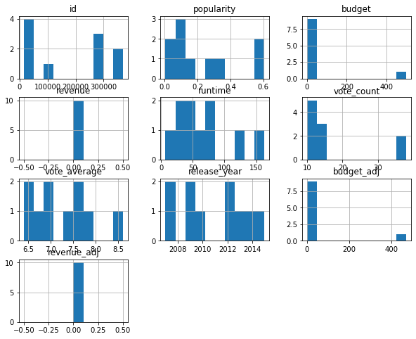

```python
#check the null values in columns
df[df.imdb_id.isnull()].hist(figsize=(10,8))
```

```python
#fill the null values with values
df.fillna(df.mean(), inplace=True)
df.info()
```

```
<class 'pandas.core.frame.DataFrame'>
RangeIndex: 10866 entries, 0 to 10865
Data columns (total 17 columns):
 #   Column          Non-Null Count  Dtype
---  ------          --------------  -----
 0   id              10866 non-null  int64
 1   imdb_id         10856 non-null  object
 2   popularity      10866 non-null  float64
 3   budget          10866 non-null  int64
 4   revenue         10866 non-null  int64
 5   original_title  10866 non-null  object
 6   cast            10790 non-null  object
 7   director        10822 non-null  object
 8   overview        10862 non-null  object
 9   runtime         10866 non-null  int64
 10  genres          10843 non-null  object
 11  release_date    10866 non-null  object
 12  vote_count      10866 non-null  int64
 13  vote_average    10866 non-null  float64
 14  release_year    10866 non-null  int64
 15  budget_adj      10866 non-null  float64
 16  revenue_adj     10866 non-null  float64
dtypes: float64(4), int64(6), object(7)
memory usage: 1.4+ MB
```

```python
#drop the null values
df.dropna(inplace=True)
df.info()
```

```
<class 'pandas.core.frame.DataFrame'>
Int64Index: 10725 entries, 0 to 10865
Data columns (total 17 columns):
 #   Column          Non-Null Count  Dtype
---  ------          --------------  -----
 0   id              10725 non-null  int64
 1   imdb_id         10725 non-null  object
 2   popularity      10725 non-null  float64
 3   budget          10725 non-null  int64
 4   revenue         10725 non-null  int64
 5   original_title  10725 non-null  object
 6   cast            10725 non-null  object
 7   director        10725 non-null  object
 8   overview        10725 non-null  object
 9   runtime         10725 non-null  int64
 10  genres          10725 non-null  object
 11  release_date    10725 non-null  object
 12  vote_count      10725 non-null  int64
 13  vote_average    10725 non-null  float64
 14  release_year    10725 non-null  int64
 15  budget_adj      10725 non-null  float64
 16  revenue_adj     10725 non-null  float64
dtypes: float64(4), int64(6), object(7)
memory usage: 1.5+ MB
```

```python
df.shape
```

```
(10725, 17)
```

> After cleaning the dataset. The dataset now has 10725 rows and 17 columns.

> The columns that remained after the cleaning: id, imdb_id, popularity, budget, revenue, original_title, cast, director, overview, runtime, genres, release_date, vote_count, vote_average, release_year, budget_adj, revenue_adje

## Exploratory Data Analysis

#### Description of the data

```python
df.describe()
```

|  | id | popularity | budget | revenue | runtime | vote_count | vote_average | release_year | budget_adj | revenue_adj |
| --- | --- | --- | --- | --- | --- | --- | --- | --- | --- | --- |
| count | 10725.000000 | 10725.000000 | 1.072500e+04 | 1.072500e+04 | 10725.000000 | 10725.000000 | 10725.000000 | 10725.000000 | 1.072500e+04 | 1.072500e+04 |
| mean | 65182.327925 | 0.652852 | 1.481473e+07 | 4.034253e+07 | 102.502471 | 219.933054 | 5.964317 | 2001.255012 | 1.777804e+07 | 5.203541e+07 |
| std | 91470.421976 | 1.005025 | 3.107129e+07 | 1.176814e+08 | 30.458857 | 578.955633 | 0.930166 | 12.822147 | 3.447315e+07 | 1.454606e+08 |
| min | 5.000000 | 0.000188 | 0.000000e+00 | 0.000000e+00 | 0.000000 | 10.000000 | 1.500000 | 1960.000000 | 0.000000e+00 | 0.000000e+00 |
| 25% | 10546.000000 | 0.210766 | 0.000000e+00 | 0.000000e+00 | 90.000000 | 17.000000 | 5.400000 | 1995.000000 | 0.000000e+00 | 0.000000e+00 |
| 50% | 20309.000000 | 0.387304 | 0.000000e+00 | 0.000000e+00 | 99.000000 | 39.000000 | 6.000000 | 2006.000000 | 0.000000e+00 | 0.000000e+00 |
| 75% | 73937.000000 | 0.721548 | 1.600000e+07 | 2.500526e+07 | 112.000000 | 148.000000 | 6.600000 | 2011.000000 | 2.113258e+07 | 3.476553e+07 |
| max | 417859.000000 | 32.985763 | 4.250000e+08 | 2.781506e+09 | 900.000000 | 9767.000000 | 9.200000 | 2015.000000 | 4.250000e+08 | 2.827124e+09 |

#### Question 1: Actor appearances

```python
# actor appearances in the movies
df['cast'].head(10)
```

```
0    Chris Pratt|Bryce Dallas Howard|Irrfan Khan|Vi...
1    Tom Hardy|Charlize Theron|Hugh Keays-Byrne|Nic...
2    Shailene Woodley|Theo James|Kate Winslet|Ansel...
3    Harrison Ford|Mark Hamill|Carrie Fisher|Adam D...
4    Vin Diesel|Paul Walker|Jason Statham|Michelle ...
5    Leonardo DiCaprio|Tom Hardy|Will Poulter|Domhn...
6    Arnold Schwarzenegger|Jason Clarke|Emilia Clar...
7    Matt Damon|Jessica Chastain|Kristen Wiig|Jeff ...
8    Sandra Bullock|Jon Hamm|Michael Keaton|Allison...
9    Amy Poehler|Phyllis Smith|Richard Kind|Bill Ha...
Name: cast, dtype: object
```

[figure not shown]

```python
df['cast'].head(50).hist(figsize=(10,8))
```

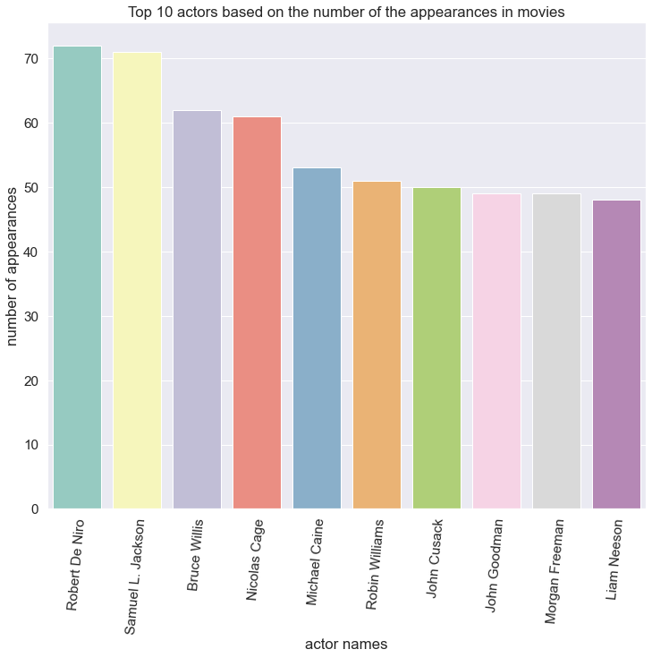

```python
#create a dictionary
actor_dict = {}

#isolate the cast column
actor = df["cast"]
#remove the | dividing the actor names
actor = actor.str.split("|")
#change pandas dataframe to a numpy array
actor = np.array(actor)
for a in actor:
    for actor in a:
        if actor not in actor_dict:
            actor_dict[actor] = 1
        else:
            actor_dict[actor] += 1

sorted_actor = sorted(actor_dict.items(), key = operator.itemgetter(1), reverse = True)

x_axis = list()
y_axis = list()

for item in sorted_actor[0:10]:
    x_axis.append(item[0])
    y_axis.append(item[1])

sns.set(rc={'figure.figsize':(12,10)}, font_scale=1.4)
ax = sns.barplot(x_axis, y_axis, palette="Set3")

#rotate x-axis' text
for item in ax.get_xticklabels():
    item.set_rotation(85)


ax.set(xlabel='actor names', ylabel='number of appearances', title = 'Top 10 actors based on the number of the appearances in movies')
plt.show()
```

#### Question 2: Top movies

#### 2.1: Top movies based on average votes

```
<function matplotlib.pyplot.show(close=None, block=None)>
```

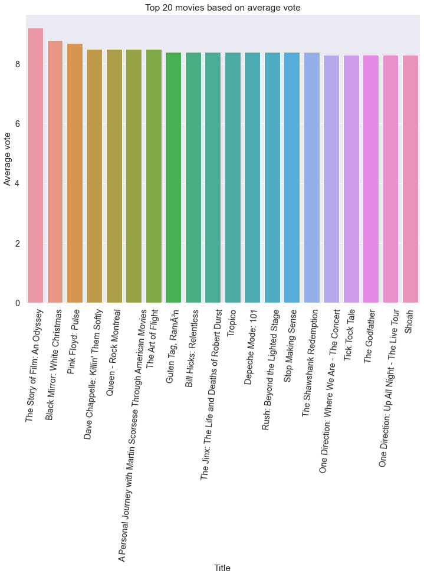

```python
#fetch average vote and movies
vote_and_movies = df[["original_title", "vote_average"]]

sns.set(rc={'figure.figsize':(12,9)}, font_scale=1.3)

ax = sns.barplot(vote_and_movies.sort_values(by="vote_average", ascending=False).head(20).original_title,
vote_and_movies.sort_values(by="vote_average", ascending=False).head(20).vote_average)

#rotate x-axis text
for item in ax.get_xticklabels():
    item.set_rotation(85)

ax.set(xlabel='Title', ylabel='Average vote', title='Top 20 movies based on average vote')
plt.show
```

```
<function matplotlib.pyplot.show(close=None, block=None)>
```

[figure not shown]

```python
#fetch average vote and movies
vote_and_movies = df[["original_title", "vote_average"]]

sns.set(rc={'figure.figsize':(12,9)}, font_scale=1.3)

ax = sns.barplot(vote_and_movies.sort_values(by="vote_average", ascending=False).tail(20).original_title,
vote_and_movies.sort_values(by="vote_average", ascending=False).tail(20).vote_average)

#rotate x-axis text
for item in ax.get_xticklabels():
    item.set_rotation(85)

ax.set(xlabel='Title', ylabel='Average vote', title='Last 20 movies based on average vote')
plt.show
```

#### 2.2: Top movies based on popularity

```
<function matplotlib.pyplot.show(close=None, block=None)>
```

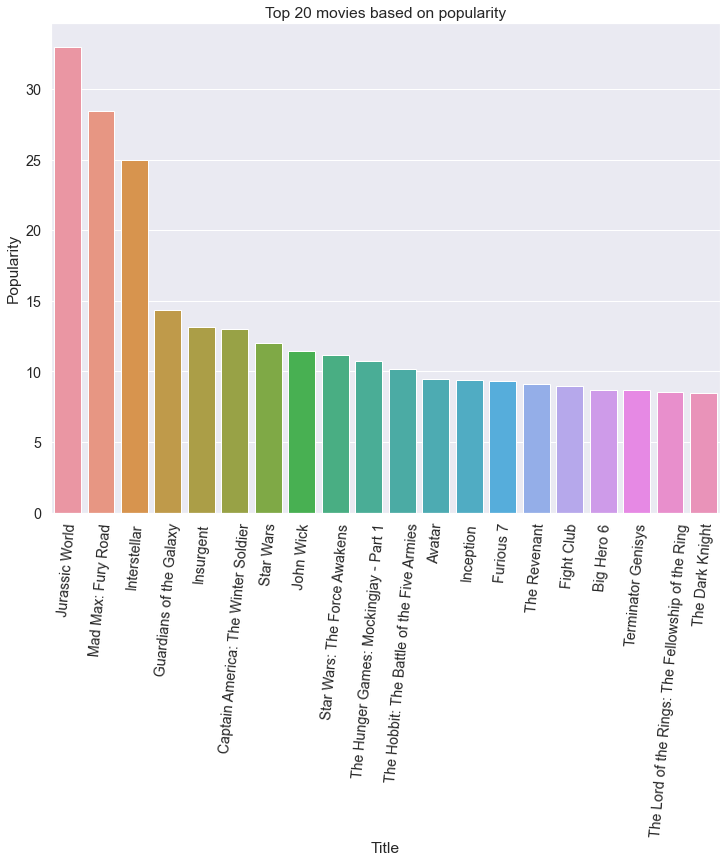

```python
#fetch popularity and movies
popularity_and_movies = df[["original_title", "popularity"]]

sns.set(rc={'figure.figsize':(12,9)}, font_scale=1.3)

ax = sns.barplot(popularity_and_movies.sort_values(by="popularity", ascending=False).head(20).original_title,
popularity_and_movies.sort_values(by="popularity", ascending=False).head(20).popularity)

#rotate x-axis text
for item in ax.get_xticklabels():
    item.set_rotation(85)

ax.set(xlabel='Title', ylabel='Popularity', title='Top 20 movies based on popularity')
plt.show
```

```
<function matplotlib.pyplot.show(close=None, block=None)>
```

[figure not shown]

```python
#fetch popularity and movies
popularity_and_movies = df[["original_title", "popularity"]]

sns.set(rc={'figure.figsize':(12,9)}, font_scale=1.3)

ax = sns.barplot(popularity_and_movies.sort_values(by="popularity", ascending=False).tail(20).original_title,
popularity_and_movies.sort_values(by="popularity", ascending=False).tail(20).popularity)

#rotate x-axis text
for item in ax.get_xticklabels():
    item.set_rotation(85)

ax.set(xlabel='Title', ylabel='Popularity', title='Last 20 movies based on popularity')
plt.show
```

#### 2.3: Top movies based on revenue

```
<function matplotlib.pyplot.show(close=None, block=None)>
```

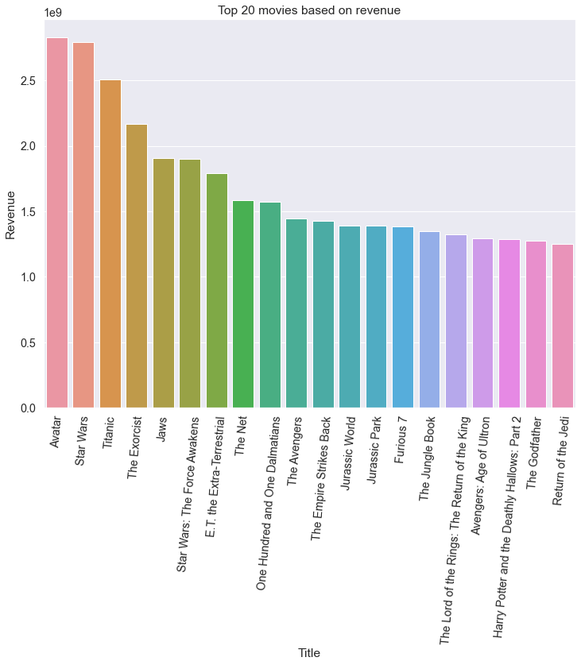

```python
#fetch revenue and movies
revenue_and_movies = df[["original_title", "revenue_adj"]]

sns.set(rc={'figure.figsize':(12,9)}, font_scale=1.3)

ax = sns.barplot(revenue_and_movies.sort_values(by="revenue_adj", ascending=False).head(20).original_title,
revenue_and_movies.sort_values(by="revenue_adj", ascending=False).head(20).revenue_adj)

#rotate x-axis text
for item in ax.get_xticklabels():
    item.set_rotation(85)

ax.set(xlabel='Title', ylabel='Revenue', title='Top 20 movies based on revenue')
plt.show
```

```
<function matplotlib.pyplot.show(close=None, block=None)>
```

[figure not shown]

```python
#fetch revenue and movies
revenue_and_movies = df[["original_title", "revenue_adj"]]

sns.set(rc={'figure.figsize':(12,9)}, font_scale=1.3)

ax = sns.barplot(revenue_and_movies.sort_values(by="revenue_adj", ascending=False).tail(20).original_title,
revenue_and_movies.sort_values(by="revenue_adj", ascending=False).tail(20).revenue_adj)

#rotate x-axis text
for item in ax.get_xticklabels():
    item.set_rotation(85)

ax.set(xlabel='Title', ylabel='Revenue', title='Last 20 movies based on revenue')
plt.show
```

#### 2.4: Top movies based on budget

```
<function matplotlib.pyplot.show(close=None, block=None)>
```

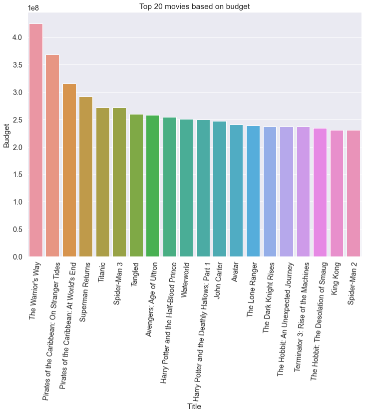

```python
#fetch budget and movies
budget_and_movies = df[["original_title", "budget_adj"]]

sns.set(rc={'figure.figsize':(12,9)}, font_scale=1.3)

ax = sns.barplot(budget_and_movies.sort_values(by="budget_adj", ascending=False).head(20).original_title,
budget_and_movies.sort_values(by="budget_adj", ascending=False).head(20).budget_adj)

#rotate x-axis text
for item in ax.get_xticklabels():
    item.set_rotation(85)

ax.set(xlabel='Title', ylabel='Budget', title='Top 20 movies based on budget')
plt.show
```

```
<function matplotlib.pyplot.show(close=None, block=None)>
```

[figure not shown]

```python
#fetch budget and movies
budget_and_movies = df[["original_title", "budget_adj"]]

sns.set(rc={'figure.figsize':(12,9)}, font_scale=1.3)

ax = sns.barplot(budget_and_movies.sort_values(by="budget_adj", ascending=False).tail(20).original_title,
budget_and_movies.sort_values(by="budget_adj", ascending=False).tail(20).budget_adj)

#rotate x-axis text
for item in ax.get_xticklabels():
    item.set_rotation(85)

ax.set(xlabel='Title', ylabel='Budget', title='Last 20 movies based on budget')
plt.show
```

#### 2.5: Top movies based on runtime

```
<function matplotlib.pyplot.show(close=None, block=None)>
```

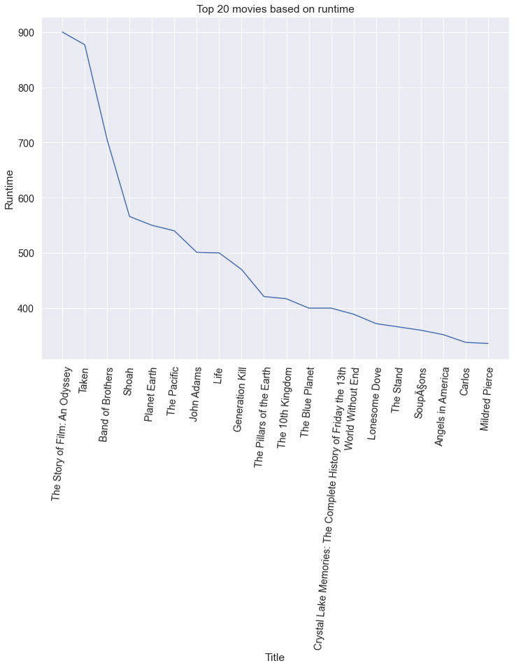

```python
#fetch runtime and movies
runtime_and_movies = df[["original_title", "runtime"]]

sns.set(rc={'figure.figsize':(12,9)}, font_scale=1.3)

ax = sns.lineplot(runtime_and_movies.sort_values(by="runtime", ascending=False).head(20).original_title,
runtime_and_movies.sort_values(by="runtime", ascending=False).head(20).runtime)

#rotate x-axis text
for item in ax.get_xticklabels():
    item.set_rotation(85)

ax.set(xlabel='Title', ylabel='Runtime', title='Top 20 movies based on runtime')
plt.show
```

```
<function matplotlib.pyplot.show(close=None, block=None)>
```

[figure not shown]

```python
#fetch runtime and movies
runtime_and_movies = df[["original_title", "runtime"]]

sns.set(rc={'figure.figsize':(12,9)}, font_scale=1.3)

ax = sns.lineplot(runtime_and_movies.sort_values(by="runtime", ascending=False).tail(20).original_title,
runtime_and_movies.sort_values(by="runtime", ascending=False).tail(20).runtime)

#rotate x-axis text
for item in ax.get_xticklabels():
    item.set_rotation(85)

ax.set(xlabel='Title', ylabel='Runtime', title='Last 20 movies based on runtime')
plt.show
```